# RepData_PeerAssessment1

Amanda Molling

Saturday, March 14, 2015

This is the summary of the data that was read in:

```r
unzip("activity.zip")
 activityData <- read.csv("activity.csv")
summary(activityData)
```

```
##      steps                date          interval
##  Min.   :  0.00   2012-10-01:  288   Min.   :   0.0
##  1st Qu.:  0.00   2012-10-02:  288   1st Qu.: 588.8
##  Median :  0.00   2012-10-03:  288   Median :1177.5
##  Mean   : 37.38   2012-10-04:  288   Mean   :1177.5
##  3rd Qu.: 12.00   2012-10-05:  288   3rd Qu.:1766.2
##  Max.   :806.00   2012-10-06:  288   Max.   :2355.0
##  NA's   :2304     (Other)   :15840
```

```r
head(activityData)
```

```
##   steps       date interval
## 1    NA 2012-10-01        0
## 2    NA 2012-10-01        5
## 3    NA 2012-10-01       10
## 4    NA 2012-10-01       15
## 5    NA 2012-10-01       20
## 6    NA 2012-10-01       25
```

If I wanted to convert my dates to type date, I could use.

```r
activityData$date <- as.Date(activityData$date)
```

```r
totalDailySteps <- aggregate(steps ~ date, activityData, sum)
meanDailySteps <- aggregate(steps ~ date, activityData, mean)
medDailySteps <- aggregate(steps ~ date, activityData, mean)

head(totalDailySteps)
```

```
##         date steps
## 1 2012-10-02   126
## 2 2012-10-03 11352
## 3 2012-10-04 12116
## 4 2012-10-05 13294
## 5 2012-10-06 15420
## 6 2012-10-07 11015
```

Then my histogram:

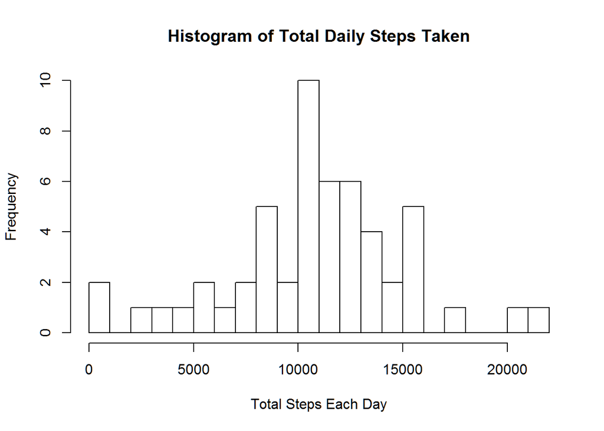

```r
hist(totalDailySteps[, 2], breaks = 20, xlab = "Total Steps Each Day", main = "Histogram of Total Daily Steps Taken")
```

Followed by analysis on that data:

```r
mean(totalDailySteps[, 2])
```

```
## [1] 10766.19
```

```r
median(totalDailySteps[,2])
```

```
## [1] 10765
```

Further analysis comparing the average number of steps at each time interval across the days yields:

```r
meanDailyStepsByInterval <- aggregate(steps ~ interval, activityData, mean)
library('lattice')
```

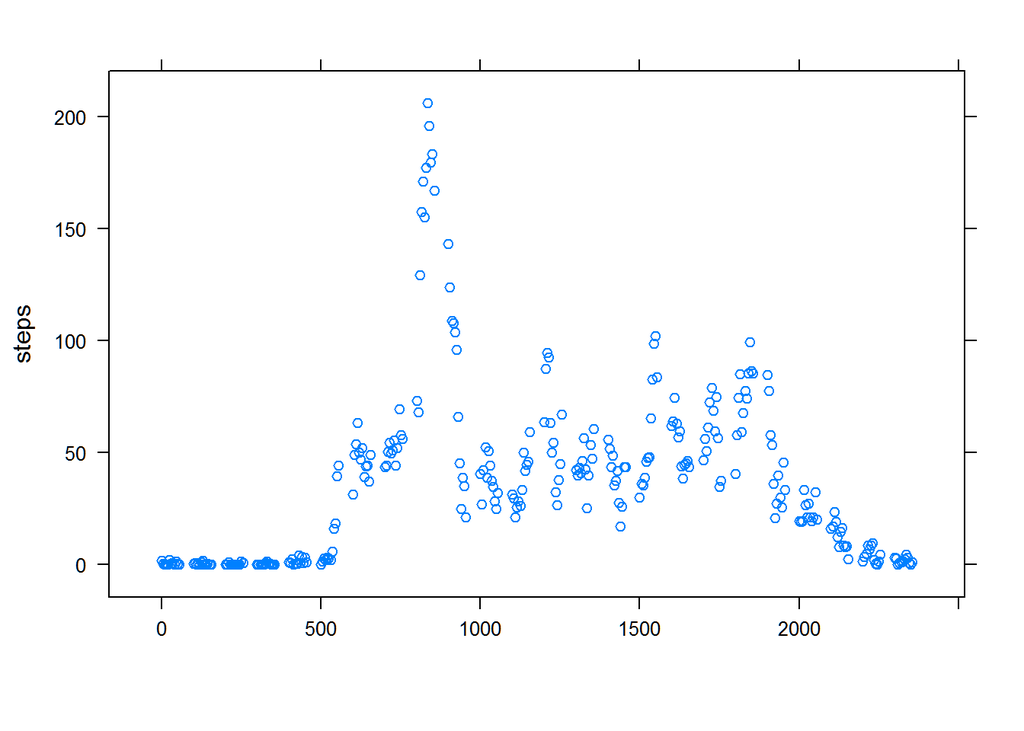

```r
xyplot(steps ~ interval, meanDailyStepsByInterval, xlab = "
       ")
```

The time interval with the most steps is found to be 835.

```r
which(meanDailyStepsByInterval == max(meanDailyStepsByInterval[2]), arr.ind = TRUE)
```

```
##      row col
## [1,] 104   2
```

where the value is:

```r
max(meanDailyStepsByInterval[,2])
```

```
## [1] 206.1698
```

```r
## And the specific interval is :

meanDailyStepsByInterval[104, 1]
```

```
## [1] 835
```

For the second part, I find the number of complete cases and build a table. Then, I can subtract the good cases from the total number of obs. Another way to do this is by simply calculating the number of bad cases as shown.

```r
##I make the good data first
good <-complete.cases(activityData)

goodData<-activityData[good,][,]
nrow(goodData)
```

```
## [1] 15264
```

```r
nrow(activityData) - nrow(goodData)
```

```
## [1] 2304
```

```r
##That is the number of bad rows
## The second method:
badData <- activityData[!good,][,]
nrow(badData)
```

```
## [1] 2304
```